# Replication

## Day 1 - Concepts and Measures

The research question is “Does incumbency in Brazil improve your performance at the next election?”. The research methodology is a regression discontinuity comparing close winners and losers. You have been provided with the raw data and need to prepare it for the analysis (but not do the analysis itself).

1. What is the data sample used to answer the research question? What alternative data samples might have been used?
2. Filter both datasets to exlude the data from second-round elections. How does this alter the data sample?
3. What is the unit of analysis in the dataset? What alternative units of analysis could have been used?
4. With the 2004 data, calculate the outcome variable, “performance at the next election”. What different measures are available?
5. With the 2000 data, create a measure of how “close” were the winners and losers to the threshold (of a tied election). What alternative measures could have been used?
6. With the 2000 data, create a measure of ‘incumbency’ for the period 2000-2004. What are the alternative measures available?
7. Merge the 2000 and 2004 data into a single dataset. What ‘keys’ do you need to use? What type of join did you perform?
8. Save your processed dataset! We will use it tomorrow.

```r
d_2000 <- read_csv("2000 Mayoral Elections Data.csv")
d_2004 <- read_csv("2004 Mayoral Elections Data.csv")
d_2000 <- d_2000 %>% filter(NUM_TURNO==1) %>%
  group_by(COD_MUN_IBGE) %>%
  mutate(vote_pct_2000=QTDE_VOTOS/sum(QTDE_VOTOS)) %>%
  mutate(rank_2000=rank(-QTDE_VOTOS)) %>%
  arrange(COD_MUN_IBGE,rank_2000) %>%
  mutate(first_rank_vote_pct=max(vote_pct_2000), second_rank_vote_pct=nth(vote_pct_2000,2)) %>%
  mutate(win_margin=ifelse(rank_2000==1,vote_pct_2000-second_rank_vote_pct,vote_pct_2000-first_rank_vote_pct)) %>%
  mutate(Incumbent=ifelse(rank_2000==1,1,0))

d_2004 <- d_2004 %>% filter(NUM_TURNO==1) %>%
  select(COD_MUN_IBGE,SIGLA_PARTIDO,QTDE_VOTOS) %>%
  group_by(COD_MUN_IBGE) %>%
  mutate(vote_pct_2004=QTDE_VOTOS/sum(QTDE_VOTOS))

d <- d_2000 %>% left_join(d_2004,by=c("COD_MUN_IBGE","SIGLA_PARTIDO"))
```

## Day 2 - Observational regression

Using your dataset from Day 1, what would the answer to our research question be using an ‘observational’ methodology?

1. Conduct a basic regression of incumbency status on (your measure of) electoral performance in 2004. Interpret the results. (Hint: Make sure your measure of distance to the tied election has negative values for the losers).
2. Are these results consistent with the finding in Titiunik 2011?
3. Briefly describe the treatment assignment process.
4. One causal critique might be that there is omitted variable bias: More effective or popular parties are more likely to become incumbents and also to perform better at the next election. To try and adjust for this, add a control for party (equivalently, a fixed effect for party). How does this affect the results?
5. What happens if we add a control for state (‘UF’)?
6. A different causal critique is that there may be selection bias. Perhaps incumbent parties who realized they are unpopular decided not to run again? We do not have these parties in our 2004 dataset. To estimate how severe this problem *might* be, calculate what percentage of parties decided to run again in 2004. (You may have to open the original datasets from Day 1 again, depending on how you joined your data).

```r
d %>% lm(vote_pct_2004~Incumbent, data=.) %>% summary()
```

```
##
## Call:
## lm(formula = vote_pct_2004 ~ Incumbent, data = .)
##
## Residuals:
##      Min       1Q   Median       3Q      Max
## -0.45860 -0.09617  0.02761  0.11415  0.63941
##
## Coefficients:
##             Estimate Std. Error t value Pr(>|t|)
## (Intercept) 0.360592   0.003090  116.69   <2e-16 ***
## Incumbent   0.098864   0.004601   21.49   <2e-16 ***
## ---
## Signif. codes:  0 '***' 0.001 '**' 0.01 '*' 0.05 '.' 0.1 ' ' 1
##
## Residual standard error: 0.1724 on 5668 degrees of freedom
##   (7879 observations deleted due to missingness)
## Multiple R-squared:  0.07534,    Adjusted R-squared:  0.07517
## F-statistic: 461.8 on 1 and 5668 DF,  p-value: < 2.2e-16
```

```r
d %>% lm(vote_pct_2004~Incumbent + SIGLA_PARTIDO, data=.) %>% summary()
```

```
##
## Call:
## lm(formula = vote_pct_2004 ~ Incumbent + SIGLA_PARTIDO, data = .)
##
## Residuals:
##      Min       1Q   Median       3Q      Max
## -0.47604 -0.08866  0.01825  0.10234  0.71855
##
## Coefficients:
##                       Estimate Std. Error t value Pr(>|t|)
## (Intercept)           0.023352   0.094148   0.248 0.804121
## Incumbent             0.073640   0.004485  16.419  < 2e-16 ***
## SIGLA_PARTIDOPC do B  0.237382   0.119089   1.993 0.046276 *
## SIGLA_PARTIDOPCB     -0.013695   0.148862  -0.092 0.926702
## SIGLA_PARTIDOPCO     -0.018858   0.110399  -0.171 0.864373
## SIGLA_PARTIDOPDT      0.341268   0.094589   3.608 0.000311 ***
## SIGLA_PARTIDOPFL      0.383151   0.094324   4.062 4.93e-05 ***
## SIGLA_PARTIDOPHS      0.166702   0.108724   1.533 0.125266
## SIGLA_PARTIDOPL       0.332148   0.094837   3.502 0.000465 ***
## SIGLA_PARTIDOPMDB     0.379472   0.094268   4.025 5.76e-05 ***
## SIGLA_PARTIDOPMN      0.277369   0.103759   2.673 0.007535 **
## SIGLA_PARTIDOPPS      0.366730   0.094867   3.866 0.000112 ***
## SIGLA_PARTIDOPRONA   -0.016698   0.124547  -0.134 0.893353
## SIGLA_PARTIDOPRP      0.186633   0.105267   1.773 0.076291 .
## SIGLA_PARTIDOPRTB     0.179429   0.115308   1.556 0.119743
## SIGLA_PARTIDOPSB      0.323262   0.095194   3.396 0.000689 ***
## SIGLA_PARTIDOPSC      0.198398   0.100376   1.977 0.048141 *
## SIGLA_PARTIDOPSDB     0.376310   0.094315   3.990 6.69e-05 ***
## SIGLA_PARTIDOPSDC     0.225735   0.107350   2.103 0.035527 *
## SIGLA_PARTIDOPSL      0.351022   0.103145   3.403 0.000671 ***
## SIGLA_PARTIDOPSTU    -0.010781   0.097891  -0.110 0.912312
## SIGLA_PARTIDOPT       0.258097   0.094345   2.736 0.006245 **
## SIGLA_PARTIDOPT do B  0.212927   0.105272   2.023 0.043157 *
## SIGLA_PARTIDOPTB      0.346626   0.094619   3.663 0.000251 ***
## SIGLA_PARTIDOPTN      0.130027   0.124552   1.044 0.296548
## SIGLA_PARTIDOPV       0.204881   0.099246   2.064 0.039028 *
## ---
## Signif. codes:  0 '***' 0.001 '**' 0.01 '*' 0.05 '.' 0.1 ' ' 1
##
## Residual standard error: 0.1631 on 5644 degrees of freedom
##   (7879 observations deleted due to missingness)
## Multiple R-squared:  0.176,  Adjusted R-squared:  0.1724
## F-statistic: 48.24 on 25 and 5644 DF,  p-value: < 2.2e-16
```

```r
d %>% lm(vote_pct_2004~Incumbent + UF, data=.) %>% summary()
```

```
##
## Call:
## lm(formula = vote_pct_2004 ~ Incumbent + UF, data = .)
##
## Residuals:
##     Min      1Q  Median      3Q     Max
## -0.4925 -0.0919  0.0238  0.1108  0.6402
##
## Coefficients:
##              Estimate Std. Error t value Pr(>|t|)
## (Intercept)  0.388077   0.084948   4.568 5.02e-06 ***
## Incumbent    0.092824   0.004566  20.329  < 2e-16 ***
## UFAL        -0.005023   0.086883  -0.058   0.9539
## UFAM        -0.085027   0.088032  -0.966   0.3342
## UFAP        -0.268475   0.147126  -1.825   0.0681 .
## UFBA        -0.035073   0.085332  -0.411   0.6811
## UFCE         0.012215   0.085791   0.142   0.8868
## UFES        -0.038191   0.087407  -0.437   0.6622
## UFGO        -0.018807   0.085576  -0.220   0.8261
## UFMA        -0.212705   0.113960  -1.866   0.0620 .
## UFMG        -0.013574   0.085116  -0.159   0.8733
## UFMS        -0.011829   0.086831  -0.136   0.8916
## UFMT        -0.066634   0.087979  -0.757   0.4488
## UFPA        -0.054617   0.086220  -0.633   0.5265
## UFPB         0.019016   0.085739   0.222   0.8245
## UFPE         0.002206   0.085745   0.026   0.9795
## UFPI         0.018546   0.085668   0.216   0.8286
## UFPR        -0.028276   0.085407  -0.331   0.7406
## UFRJ        -0.153555   0.086258  -1.780   0.0751 .
## UFRN         0.006122   0.086048   0.071   0.9433
## UFRO        -0.068919   0.087597  -0.787   0.4315
## UFRR        -0.179081   0.129749  -1.380   0.1676
## UFRS        -0.012097   0.085222  -0.142   0.8871
## UFSC        -0.017469   0.085429  -0.204   0.8380
## UFSE         0.077972   0.147161   0.530   0.5962
## UFSP        -0.053308   0.085128  -0.626   0.5312
## ---
## Signif. codes:  0 '***' 0.001 '**' 0.01 '*' 0.05 '.' 0.1 ' ' 1
##
## Residual standard error: 0.1699 on 5644 degrees of freedom
##   (7879 observations deleted due to missingness)
## Multiple R-squared:  0.1058, Adjusted R-squared:  0.1018
## F-statistic: 26.71 on 25 and 5644 DF,  p-value: < 2.2e-16
```

```r
d %>% filter(Incumbent==1) %>% mutate(ran_in_2004=ifelse(is.na(vote_pct_2004),"No","Yes")) %>% group_by(ran_in_2004) %>% count() %>%
  ungroup() %>%
  mutate(pct_ran_in_2004=n/sum(n))
```

```
## # A tibble: 2 x 3
##   ran_in_2004     n pct_ran_in_2004
##   <chr>       <int>           <dbl>
## 1 No           2451           0.489
## 2 Yes          2558           0.511
```

## Day 3 - Causal regression

To overcome the causal problems we saw yesterday, Titiunik implements a regression discontinuity.

1. Implement the regression discontinuity using your measure of ‘close elections’, your indicator of incumbency status and your measure of electoral performance in 2004.
2. Interpret the findings of the regression discontinuity. How do they differ from the observational results in Day 2?
3. One assumption of our regression discontinuity is that comparing incumbents that just won and lost elections in 2000 will produce ‘balance’ on potential omitted variables. There are thousands of variables we could check, but let’s assess balance on the size of the municipality by comparing the number of voters in 2000 within 5% of a tied election.
4. How does the balance close to the threshold compare with the balance of winners and losers in the full dataset?
5. Another assumption of regression discontinuity is continuity in the distribution of the variable measuring distance to the threshold. Test this assumption by implementing a McCrary density test. What do the results show?

```r
d %>% lm(vote_pct_2004~Incumbent + win_margin, data=.) %>% summary()
```

```
##
## Call:
## lm(formula = vote_pct_2004 ~ Incumbent + win_margin, data = .)
##
## Residuals:
##      Min       1Q   Median       3Q      Max
## -0.56157 -0.09752  0.02687  0.10400  0.64222
##
## Coefficients:
##              Estimate Std. Error t value Pr(>|t|)
## (Intercept)  0.444168   0.003991 111.292  < 2e-16 ***
## Incumbent   -0.051106   0.006523  -7.834 5.59e-15 ***
## win_margin   0.383563   0.012760  30.061  < 2e-16 ***
## ---
## Signif. codes:  0 '***' 0.001 '**' 0.01 '*' 0.05 '.' 0.1 ' ' 1
##
## Residual standard error: 0.1597 on 5619 degrees of freedom
##   (7927 observations deleted due to missingness)
## Multiple R-squared:  0.201,  Adjusted R-squared:  0.2007
## F-statistic: 706.7 on 2 and 5619 DF,  p-value: < 2.2e-16
```

```r
library(rdd)
mccrary <- DCdensity(d$win_margin,cutpoint=0,verbose=TRUE)
```

```
## Using calculated bin size:  0.005
## Using calculated bandwidth:  0.165
```

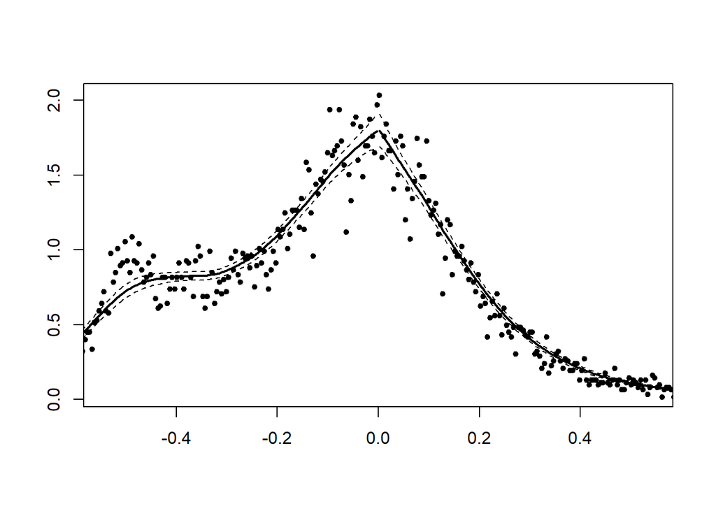

```
## Log difference in heights is  0.006  with SE  0.049
##   this gives a z-stat of  0.113
##   and a p value of  0.910
```

## Day 4 - Generalizability

How much do we learn from the regression discontinuity results estimated in Day 3? First, we will implement some robustness checks:

1. Our regression discontinuity assumed a *linear* relationship between distance to a tied election and subsequent electoral performance. Implement an alternative regression discontinuity with a more flexible quadratic relationship. How do the results differ?
2. What about a cubic relationship?
3. An alternative way to implement the regression discontinuity is to limit the data to only those units ‘close’ to the threshold of a tied election. Remove any data that is more than +/-5% from the threshold and run your (linear) regression discontinuity again. How do the results change?
4. Estimating the uncertainty (standard errors) for regression discontinuities is tricky. The ‘correct’ way to do it has been programmed in the ‘rdrobust’ package. Implement the (linear) regression discontinuity in rdrobust and compare the standard errors

We can also replicate the study with a different data sample:

5. Use the data for the 2012 and 2016 elections to implement a new regression discontinuity. Is the relationship the same as the results you estimated for 2000-04?

What about the scope of our conclusions?

6. To assess how different units near the threshold might be, let’s compare which parties are most represented near to the threshold (+/-5%) with those that win or lose by a landslide (win or lose by more than 20%).
7. Based on the above tests, how generalizable do you believe the findings in Titiunik 2011 to be?

```r
d %>% lm(vote_pct_2004~Incumbent + win_margin + I(win_margin^2), data=.) %>% summary()
```

```
##
## Call:
## lm(formula = vote_pct_2004 ~ Incumbent + win_margin + I(win_margin^2),
##     data = .)
##
## Residuals:
##      Min       1Q   Median       3Q      Max
## -0.51637 -0.09468  0.02351  0.09936  0.70531
##
## Coefficients:
##                  Estimate Std. Error t value Pr(>|t|)
## (Intercept)      0.451469   0.004057 111.288  < 2e-16 ***
## Incumbent       -0.043575   0.006542  -6.661 2.98e-11 ***
## win_margin       0.349749   0.013282  26.332  < 2e-16 ***
## I(win_margin^2) -0.183098   0.021437  -8.541  < 2e-16 ***
## ---
## Signif. codes:  0 '***' 0.001 '**' 0.01 '*' 0.05 '.' 0.1 ' ' 1
##
## Residual standard error: 0.1587 on 5618 degrees of freedom
##   (7927 observations deleted due to missingness)
## Multiple R-squared:  0.2112, Adjusted R-squared:  0.2108
## F-statistic: 501.5 on 3 and 5618 DF,  p-value: < 2.2e-16
```

```r
d %>% lm(vote_pct_2004~Incumbent + win_margin + I(win_margin^2) + I(win_margin^3), data=.) %>% summary()
```

```
##
## Call:
## lm(formula = vote_pct_2004 ~ Incumbent + win_margin + I(win_margin^2) +
##     I(win_margin^3), data = .)
##
## Residuals:
##      Min       1Q   Median       3Q      Max
## -0.51778 -0.09526  0.02339  0.09955  0.68100
##
## Coefficients:
##                  Estimate Std. Error t value Pr(>|t|)
## (Intercept)      0.455109   0.004569  99.598  < 2e-16 ***
## Incumbent       -0.050533   0.007678  -6.581 5.09e-11 ***
## win_margin       0.382251   0.023010  16.612  < 2e-16 ***
## I(win_margin^2) -0.184983   0.021461  -8.620  < 2e-16 ***
## I(win_margin^3) -0.097660   0.056461  -1.730   0.0837 .
## ---
## Signif. codes:  0 '***' 0.001 '**' 0.01 '*' 0.05 '.' 0.1 ' ' 1
##
## Residual standard error: 0.1587 on 5617 degrees of freedom
##   (7927 observations deleted due to missingness)
## Multiple R-squared:  0.2116, Adjusted R-squared:  0.2111
## F-statistic:   377 on 4 and 5617 DF,  p-value: < 2.2e-16
```

```r
window <- 0.05
d_subset <- d %>% filter(win_margin<window & win_margin>-window)

d_subset %>% lm(vote_pct_2004~win_margin+Incumbent,data=.) %>% summary()
```

```
##
## Call:
## lm(formula = vote_pct_2004 ~ win_margin + Incumbent, data = .)
##
## Residuals:
##      Min       1Q   Median       3Q      Max
## -0.44803 -0.06141  0.02339  0.08560  0.57544
##
## Coefficients:
##              Estimate Std. Error t value Pr(>|t|)
## (Intercept)  0.460611   0.009504  48.467   <2e-16 ***
## win_margin   0.313223   0.292558   1.071    0.285
## Incumbent   -0.041138   0.017058  -2.412    0.016 *
## ---
## Signif. codes:  0 '***' 0.001 '**' 0.01 '*' 0.05 '.' 0.1 ' ' 1
##
## Residual standard error: 0.144 on 1132 degrees of freedom
##   (1158 observations deleted due to missingness)
## Multiple R-squared:  0.008691,   Adjusted R-squared:  0.00694
## F-statistic: 4.962 on 2 and 1132 DF,  p-value: 0.00715
```

```r
library(rdrobust)
robust <- rdrobust(d$vote_pct_2004, d$win_margin, c=0, all=T)
robust$coef
```

```
##                      Coeff
## Conventional   -0.04117251
## Bias-Corrected -0.04309418
## Robust         -0.04309418
```

```r
robust$se
```

```
##                 Std. Err.
## Conventional   0.01049569
## Bias-Corrected 0.01049569
## Robust         0.01219411
```

```r
d %>% filter(win_margin<0.05 & win_margin>-0.05) %>%
  group_by(SIGLA_PARTIDO) %>%
  count() %>%
  ungroup() %>%
  mutate(Pct=n/sum(n)) %>%
  arrange(-Pct)
```

```
## # A tibble: 21 x 3
##    SIGLA_PARTIDO     n    Pct
##    <chr>         <int>  <dbl>
##  1 PMDB            547 0.239
##  2 PFL             394 0.172
##  3 PSDB            338 0.147
##  4 PPB             279 0.122
##  5 PTB             180 0.0785
##  6 PDT             136 0.0593
##  7 PT               91 0.0397
##  8 PL               88 0.0384
##  9 PPS              75 0.0327
## 10 PSB              59 0.0257
## # ... with 11 more rows
```

```r
d %>% filter(win_margin>0.2 | win_margin < -0.2) %>%
  group_by(SIGLA_PARTIDO) %>%
  count() %>%
  ungroup() %>%
  mutate(Pct=n/sum(n)) %>%
  arrange(-Pct)
```

```
## # A tibble: 31 x 3
##    SIGLA_PARTIDO     n    Pct
##    <chr>         <int>  <dbl>
##  1 PT              894 0.149
##  2 PMDB            834 0.139
##  3 PFL             714 0.119
##  4 PSDB            700 0.117
##  5 PPB             430 0.0718
##  6 PDT             398 0.0665
##  7 PTB             395 0.0660
##  8 PPS             303 0.0506
##  9 PL              270 0.0451
## 10 PSB             234 0.0391
## # ... with 21 more rows
```

```r
#Note PT
```

```r
d_2012 <- get_elections(year=2012, position="Mayor", regional_aggregation="Municipality", political_aggregation="Party")
d_2016 <- get_elections(year=2016, position="Mayor", regional_aggregation="Municipality", political_aggregation="Party")
d_2012 <- d_2012 %>% filter(NUM_TURNO==1) %>%
  group_by(COD_MUN_IBGE) %>%
  mutate(vote_pct_2012=QTDE_VOTOS/sum(QTDE_VOTOS)) %>%
  mutate(rank_2012=rank(-QTDE_VOTOS)) %>%
  arrange(COD_MUN_IBGE,rank_2012) %>%
  mutate(first_rank_vote_pct=max(vote_pct_2012), second_rank_vote_pct=nth(vote_pct_2012,2)) %>%
  mutate(win_margin=ifelse(rank_2012==1,vote_pct_2012-second_rank_vote_pct,vote_pct_2012-first_rank_vote_pct)) %>%
  mutate(Incumbent=ifelse(rank_2012==1,1,0))

d_2016 <- d_2016 %>% filter(NUM_TURNO==1) %>%
  select(COD_MUN_IBGE,SIGLA_PARTIDO,QTDE_VOTOS) %>%
  group_by(COD_MUN_IBGE) %>%
  mutate(vote_pct_2016=QTDE_VOTOS/sum(QTDE_VOTOS))

d_alt <- d_2012 %>% left_join(d_2016,by=c("COD_MUN_IBGE","SIGLA_PARTIDO"))

d_alt %>% lm(vote_pct_2016~Incumbent, data=.) %>% summary()
```

```
##
## Call:
## lm(formula = vote_pct_2016 ~ Incumbent, data = .)
##
## Residuals:
##      Min       1Q   Median       3Q      Max
## -0.44814 -0.11291  0.03051  0.12334  0.63172
##
## Coefficients:
##             Estimate Std. Error t value Pr(>|t|)
## (Intercept) 0.368281   0.003283  112.16   <2e-16 ***
## Incumbent   0.080420   0.004710   17.07   <2e-16 ***
## ---
## Signif. codes:  0 '***' 0.001 '**' 0.01 '*' 0.05 '.' 0.1 ' ' 1
##
## Residual standard error: 0.1858 on 6228 degrees of freedom
##   (8892 observations deleted due to missingness)
## Multiple R-squared:  0.04472,    Adjusted R-squared:  0.04457
## F-statistic: 291.6 on 1 and 6228 DF,  p-value: < 2.2e-16
```

## Day 5 - Constructive Critiques

1. If our theory is correct, we should *only* find an effect at the threshold (distance=0). Use the ‘RDestimate’ package to perform placebo tests with the threshold set to distance=0.1,-0.1,0.05 and -0.05. What do we learn from this test?
2. One theory for why incumbents may do better at the next election is due to access to state resouces. So we might expect the incumbency effect to be more positive (less negative) where state resources are more important, i.e. in the North/Northeast, and more negative in the Southeast. Implement a heterogeneity test to compare the results for just Minas Gerais (MG) and Piaui (PI).
3. Design an additional test that we could implement that would provide additional evidence that incumbency has a negative electoral impact.

```r
RDestimate(vote_pct_2004~win_margin, data=d, cutpoint=0) %>% summary()
```

```
##
## Call:
## RDestimate(formula = vote_pct_2004 ~ win_margin, data = d, cutpoint = 0)
##
## Type:
## sharp
##
## Estimates:
##            Bandwidth  Observations  Estimate  Std. Error  z value
## LATE       0.18510    3362          -0.04076  0.010067    -4.049
## Half-BW    0.09255    1959          -0.04214  0.013614    -3.095
## Double-BW  0.37020    4680          -0.03893  0.007723    -5.041
##            Pr(>|z|)
## LATE       5.147e-05  ***
## Half-BW    1.966e-03  **
## Double-BW  4.631e-07  ***
## ---
## Signif. codes:  0 '***' 0.001 '**' 0.01 '*' 0.05 '.' 0.1 ' ' 1
##
## F-statistics:
##            F       Num. DoF  Denom. DoF  p
## LATE       11.935  3         3358        1.801e-07
## Half-BW     6.689  3         1955        3.443e-04
## Double-BW  53.774  3         4676        0.000e+00
```

```r
RDestimate(vote_pct_2004~win_margin, data=d, cutpoint=0.1) %>% summary()
```

```
##
## Call:
## RDestimate(formula = vote_pct_2004 ~ win_margin, data = d, cutpoint = 0.1)
##
## Type:
## sharp
##
## Estimates:
##            Bandwidth  Observations  Estimate    Std. Error  z value
## LATE       0.13870    2354           0.0107012  0.012599     0.84939
## Half-BW    0.06935    1217          -0.0009345  0.017048    -0.05481
## Double-BW  0.27741    3943           0.0036965  0.009604     0.38491
##            Pr(>|z|)
## LATE       0.3957
## Half-BW    0.9563
## Double-BW  0.7003
## ---
## Signif. codes:  0 '***' 0.001 '**' 0.01 '*' 0.05 '.' 0.1 ' ' 1
##
## F-statistics:
##            F      Num. DoF  Denom. DoF  p
## LATE       2.090  3         2350        0.1988974
## Half-BW    1.115  3         1213        0.6839894
## Double-BW  8.004  3         3939        0.0000514
```

```r
RDestimate(vote_pct_2004~win_margin, data=d, cutpoint=-0.1) %>% summary()
```

```
##
## Call:
## RDestimate(formula = vote_pct_2004 ~ win_margin, data = d, cutpoint = -0.1)
##
## Type:
## sharp
##
## Estimates:
##            Bandwidth  Observations  Estimate   Std. Error  z value
## LATE       0.18386    3006          -0.006860  0.011555    -0.5937
## Half-BW    0.09193    1665          -0.027983  0.015698    -1.7827
## Double-BW  0.36772    4696          -0.007229  0.008661    -0.8347
##            Pr(>|z|)
## LATE       0.55269
## Half-BW    0.07464   .
## Double-BW  0.40389
## ---
## Signif. codes:  0 '***' 0.001 '**' 0.01 '*' 0.05 '.' 0.1 ' ' 1
##
## F-statistics:
##            F        Num. DoF  Denom. DoF  p
## LATE        18.929  3         3002        7.369e-12
## Half-BW      6.204  3         1661        6.890e-04
## Double-BW  113.578  3         4692        0.000e+00
```

```r
RDestimate(vote_pct_2004~win_margin, data=d, cutpoint=0.05) %>% summary()
```

```
##
## Call:
## RDestimate(formula = vote_pct_2004 ~ win_margin, data = d, cutpoint = 0.05)
##
## Type:
## sharp
##
## Estimates:
##            Bandwidth  Observations  Estimate   Std. Error  z value
## LATE       0.12293    2361           0.012490  0.012547     0.9954
## Half-BW    0.06146    1273           0.011530  0.017247     0.6685
## Double-BW  0.24585    3875          -0.001173  0.009206    -0.1274
##            Pr(>|z|)
## LATE       0.3195
## Half-BW    0.5038
## Double-BW  0.8986
## ---
## Signif. codes:  0 '***' 0.001 '**' 0.01 '*' 0.05 '.' 0.1 ' ' 1
##
## F-statistics:
##            F       Num. DoF  Denom. DoF  p
## LATE       3.3052  3         2357        0.038924
## Half-BW    0.8721  3         1269        0.909871
## Double-BW  5.6450  3         3871        0.001482
```

```r
RDestimate(vote_pct_2004~win_margin, data=d, cutpoint=-0.05) %>% summary()
```

```
##
## Call:
## RDestimate(formula = vote_pct_2004 ~ win_margin, data = d, cutpoint = -0.05)
##
## Type:
## sharp
##
## Estimates:
##            Bandwidth  Observations  Estimate   Std. Error  z value
## LATE       0.2326     3766           0.005675  0.009476     0.5989
## Half-BW    0.1163     2284           0.015526  0.012710     1.2216
## Double-BW  0.4652     5198          -0.010504  0.007328    -1.4334
##            Pr(>|z|)
## LATE       0.5492
## Half-BW    0.2219
## Double-BW  0.1517
## ---
## Signif. codes:  0 '***' 0.001 '**' 0.01 '*' 0.05 '.' 0.1 ' ' 1
##
## F-statistics:
##            F        Num. DoF  Denom. DoF  p
## LATE        20.436  3         3762        7.849e-13
## Half-BW      5.163  3         2280        2.953e-03
## Double-BW  142.629  3         5194        0.000e+00
```

```r
library(broom)

d %>% filter(UF %in% c("MG","PI")) %>%
  group_by(UF) %>%
  do(tidy(lm(vote_pct_2004~win_margin+Incumbent,data=.))) %>%
  filter(term=="Incumbent") %>%
  arrange(p.value)
```

```
## # A tibble: 2 x 6
## # Groups:   UF [2]
##   UF    term      estimate std.error statistic  p.value
##   <chr> <chr>        <dbl>     <dbl>     <dbl>    <dbl>
## 1 MG    Incumbent  -0.0984    0.0149     -6.62 5.91e-11
## 2 PI    Incumbent   0.0397    0.0267      1.49 1.39e- 1
```